# Lab 08 - Text Mining

```r
knitr::opts_chunk$set()
```

# Learning goals

- Use `unnest_tokens()` and `unnest_ngrams()` to extract tokens and ngrams from text.
- Use dplyr and ggplot2 to analyze text data

# Lab description

For this lab we will be working with the medical record transcriptions from https://www.mtsamples.com/. And is loaded and “fairly” cleaned at https://github.com/JSC370/jsc370-2023/blob/main/data/medical_transcriptions/.

### Setup packages

You should load in `dplyr`, (or `data.table` if you want to work that way), `ggplot2` and `tidytext`. If you don’t already have `tidytext` then you can install with

```r
install.packages("tidytext")
install.packages("stopwords")
```

### Read in Medical Transcriptions

Loading in reference transcription samples from https://www.mtsamples.com/

```r
library(tidytext)
library(readr)
library(dplyr)
library(tidyr)
library(ggplot2)
data_url <- paste0(
  "https://raw.githubusercontent.com/JSC370/",
  "jsc370-2023/main/data/medical_transcriptions/mtsamples.csv"
  )
mt_samples <- read_csv(data_url)
mt_samples <- mt_samples |>
  select(description, medical_specialty, transcription)
head(mt_samples)
```

```
## # A tibble: 6 × 3
##   description                                                    medic…¹ trans…²
##   <chr>                                                          <chr>   <chr>
## 1 A 23-year-old white female presents with complaint of allergi… Allerg… "SUBJE…
## 2 Consult for laparoscopic gastric bypass.                       Bariat… "PAST …
## 3 Consult for laparoscopic gastric bypass.                       Bariat… "HISTO…
## 4 2-D M-Mode. Doppler.                                           Cardio… "2-D M…
## 5 2-D Echocardiogram                                             Cardio… "1.  T…
## 6 Morbid obesity.  Laparoscopic antecolic antegastric Roux-en-Y… Bariat… "PREOP…
## # … with abbreviated variable names ¹medical_specialty, ²transcription
```

## Question 1: What specialties do we have?

We can use `count()` from `dplyr` to figure out how many different categories we have. Are these categories related? overlapping? evenly distributed?

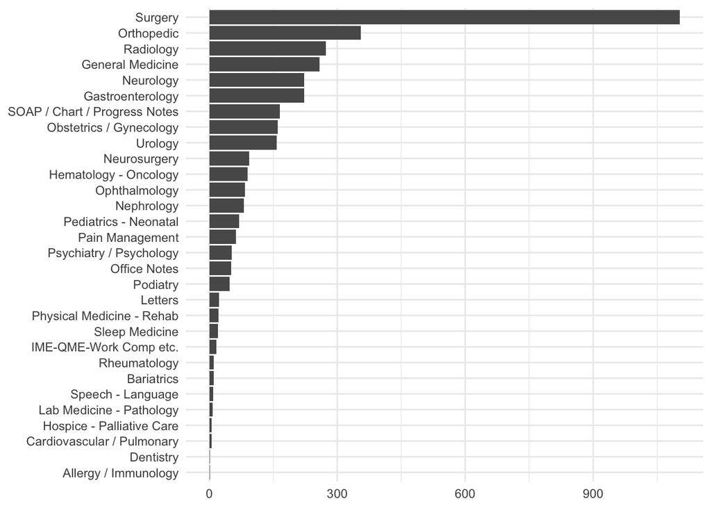

```r
mt_samples |>
  count(medical_specialty, sort = TRUE) |>
  mutate(medical_specialty = forcats::fct_reorder(medical_specialty, n)) |>
  ggplot(aes(medical_specialty, n)) +
  theme_minimal() +
  labs(y = NULL, x = NULL) +
  geom_col() +
  coord_flip()
```

## Question 2

- Tokenize the the words in the `transcription` column
- Count the number of times each token appears
- Visualize the top 20 most frequent words

Explain what we see from this result. Does it makes sense? What insights (if any) do we get?

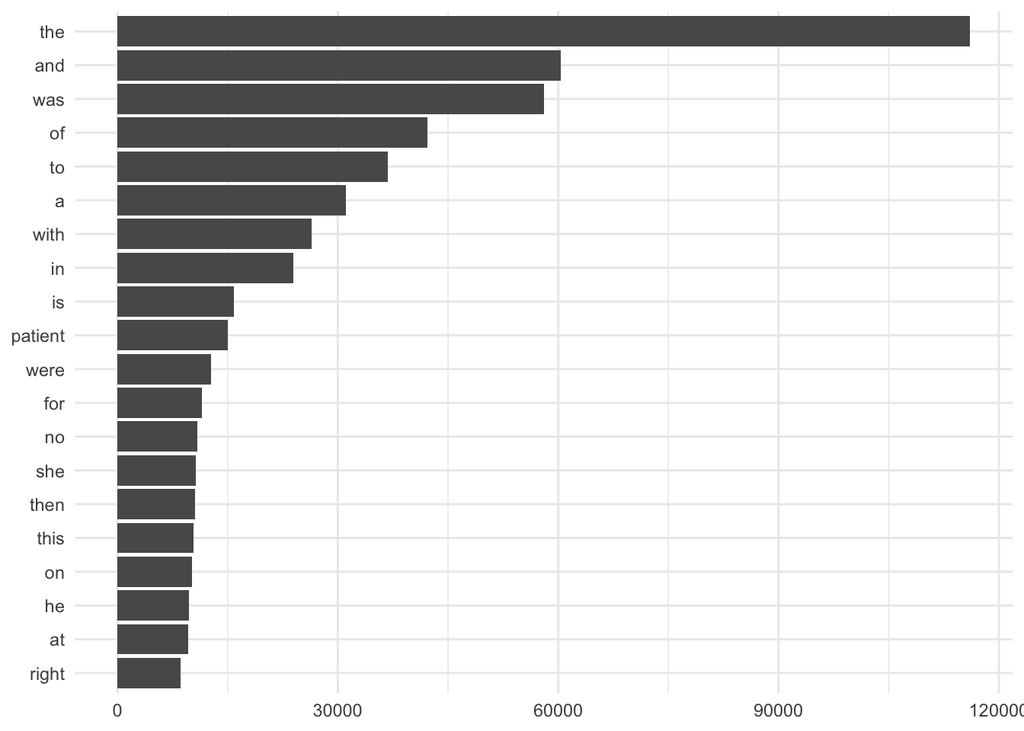

```r
tokens <- mt_samples |>
  select(transcription) |>
  unnest_tokens(word, transcription) |>
  # group_by(word) |>
  # summarise(n = n()) # same as `count(word)`
  count(word)

tokens |>
  # arrange(across(n, desc)) |>
  # head(20) |> # same as `slice_max(n, n = 20)`
  slice_max(n, n = 20) |>
  ggplot(aes(reorder(word, n), n)) +
  theme_minimal() +
  labs(y = NULL, x = NULL) +
  geom_bar(stat = "identity") +
  coord_flip()
```

## Question 3

- Redo visualization for the top 20 most frequent words after removing stop words
- Bonus points if you remove numbers as well

What do we see know that we have removed stop words? Does it give us a better idea of what the text is about?

```r
library(stopwords)
head(stopwords("english"))
```

```
## [1] "i"      "me"     "my"     "myself" "we"     "our"
```

```r
length(stopwords("english"))
```

```
## [1] 175
```

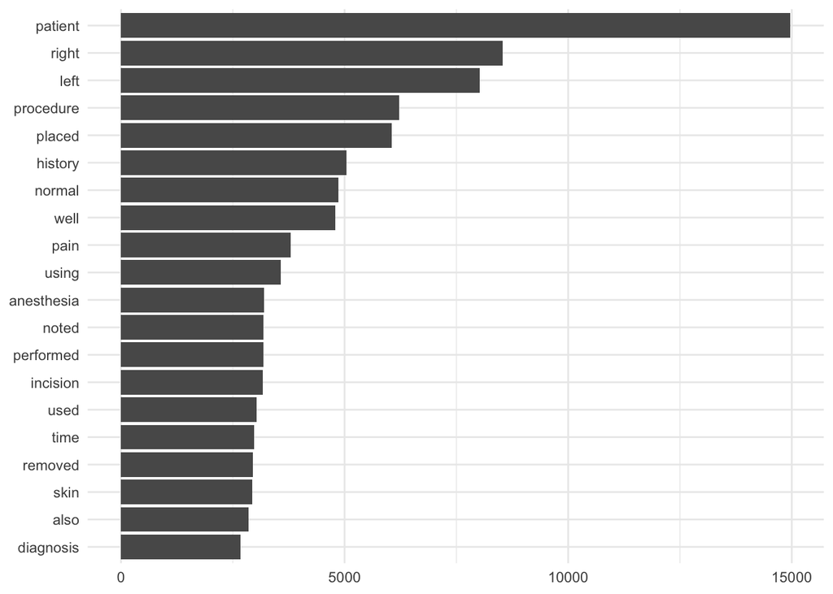

```r
tokens_no_stopwords <- tokens |>
  filter(
    !(word %in% stopwords("english")),
    !grepl("[[:digit:]]+", word)
  )

tokens_no_stopwords |>
  slice_max(n, n = 20) |>
  ggplot(aes(reorder(word, n), n)) +
  theme_minimal() +
  labs(y = NULL, x = NULL) +
  geom_bar(stat = "identity") +
  coord_flip()
```

Another method for visualizing word counts is using a word cloud via `wordcloud::wordcloud()`. Create a world cloud for the top 50 most frequent words after removing stop words (and numbers).

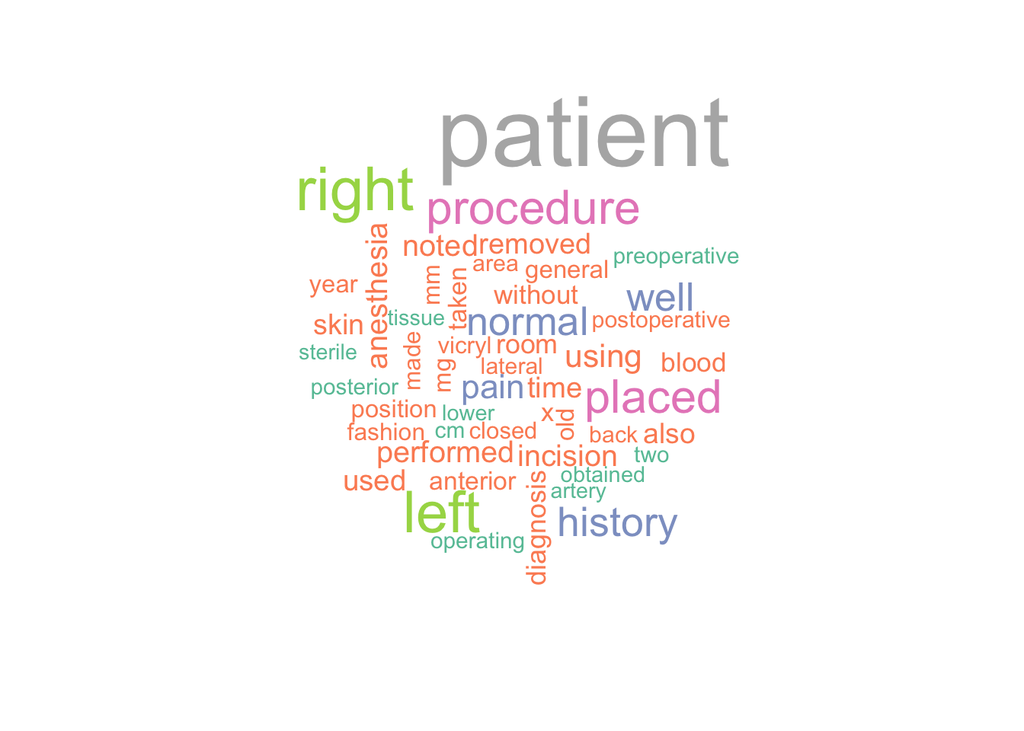

```r
library(wordcloud)
tokens50 <- tokens_no_stopwords |>
  slice_max(n, n = 50)
wordcloud(tokens50$word, tokens50$n,
          colors = brewer.pal(8, "Set2"))
```

# Question 4

Repeat question 3, but this time tokenize into bi-grams. How does the result change if you look at tri-grams? (You don’t need to create the word clouds.)

```r
# start with any of the stop words
sw_start <- paste0("^", paste(stopwords("english"), collapse = " |^"), " ")
# end with any of the stop words
sw_end <- paste0(" ", paste(stopwords("english"), collapse = "$| "), "$")
# 2-gram
tokens_bigram <- mt_samples |>
  select(transcription) |>
  unnest_tokens(ngram, transcription, token = "ngrams", n = 2) |>
  filter(
    # remove those with stop words
    !grepl(sw_start, ngram, ignore.case = TRUE),
    !grepl(sw_end, ngram, ignore.case = TRUE),
    !grepl("\\d", ngram) # remove numbers
  ) |>
  count(ngram)
# 3-gram
tokens_trigram <- mt_samples |>
  select(transcription) |>
  unnest_tokens(ngram, transcription, token = "ngrams", n = 3) |>
  filter(
    # remove those with stop words
    !grepl(sw_start, ngram, ignore.case = TRUE),
    !grepl(sw_end, ngram, ignore.case = TRUE),
    !grepl("^\\d|\\d$", ngram) # remove if end or start with a number
  ) |>
  count(ngram)
```

```r
library(stringr) # if you are more comfortable with str_*()
tokens_trigram <- mt_samples |>
  select(transcription) |>
  unnest_tokens(ngram, transcription, token = "ngrams", n = 3) |>
  filter(
    !str_detect(ngram, regex(sw_start, ignore_case = TRUE)),
    !str_detect(ngram, regex(sw_end, ignore_case = TRUE)),
    !str_detect(ngram, "\\d")
  ) |>
  count(ngram)
```

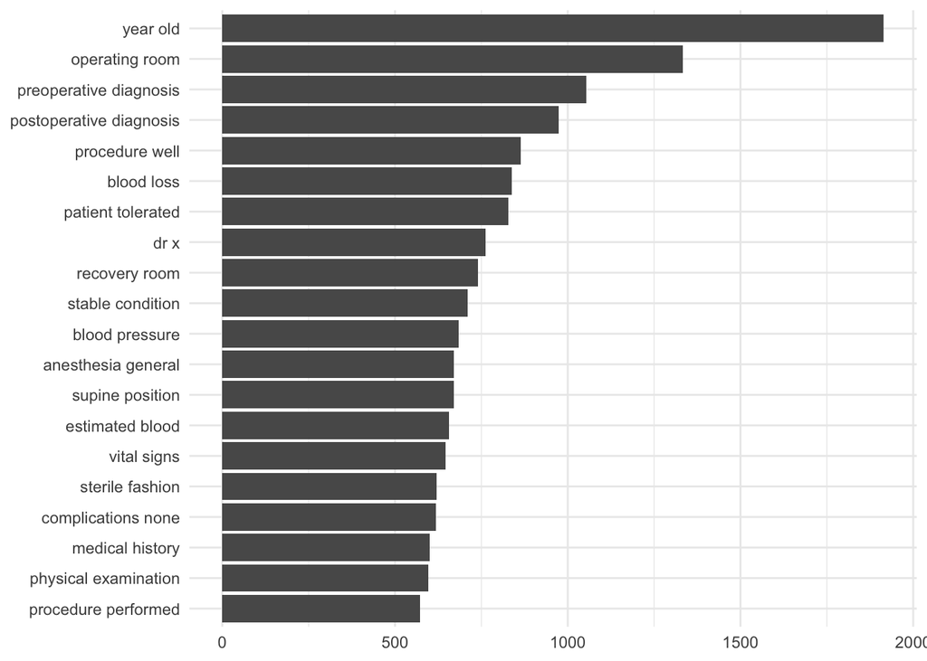

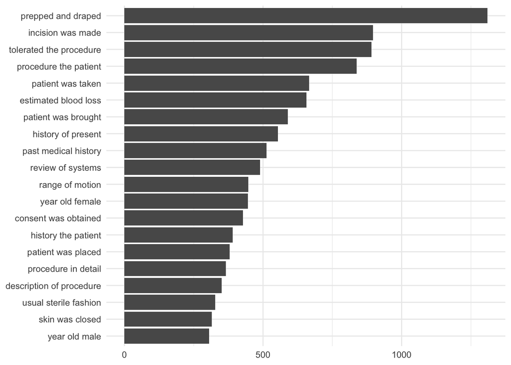

```r
tokens_bigram |>
  slice_max(n, n = 20) |>
  ggplot(aes(reorder(ngram, n), n)) +
  theme_minimal() +
  labs(y = NULL, x = NULL) +
  geom_bar(stat = 'identity') +
  coord_flip()
tokens_trigram |>
  slice_max(n, n = 20) |>
  ggplot(aes(reorder(ngram, n), n)) +
  theme_minimal() +
  labs(y = NULL, x = NULL) +
  geom_bar(stat = 'identity') +
  coord_flip()
```

The word clouds aren’t as helpful as the word cloud with “words”.

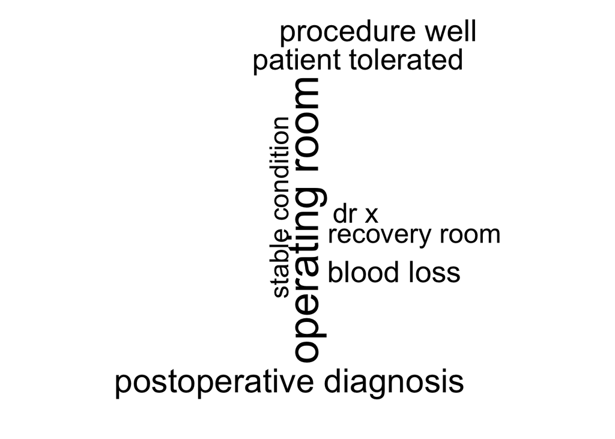

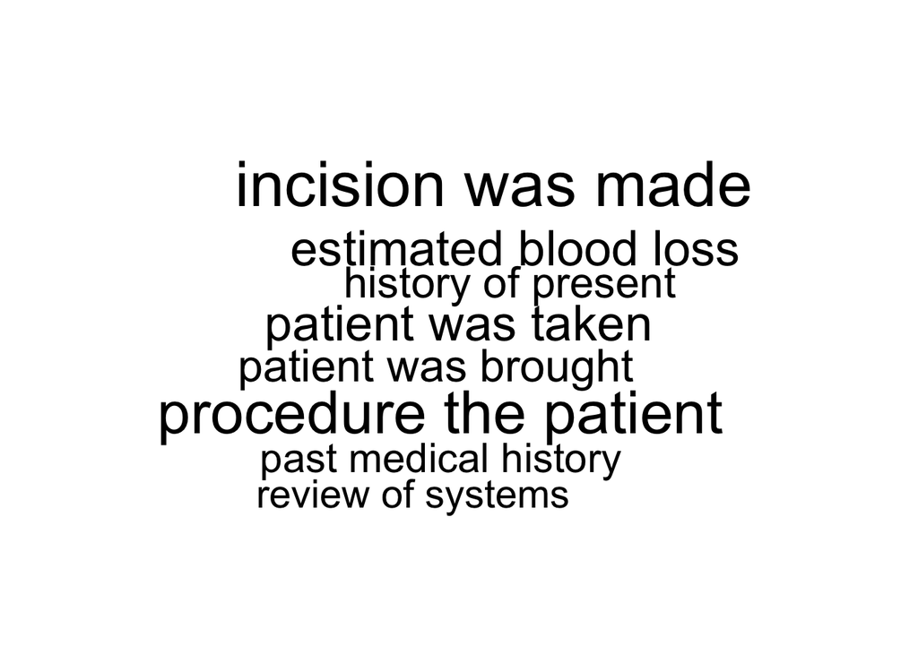

```r
tokens10_bigram <- tokens_bigram |>
  arrange(across(n, desc)) |>
  head(10)
tokens10_trigram <- tokens_trigram |>
  arrange(across(n, desc)) |>
  head(10)
wordcloud(tokens10_bigram$ngram, tokens10_bigram$n)
wordcloud(tokens10_trigram$ngram, tokens10_trigram$n)
```

# Question 5

Using the results you got from question 4. Pick a word and count the words that appears after or before it.

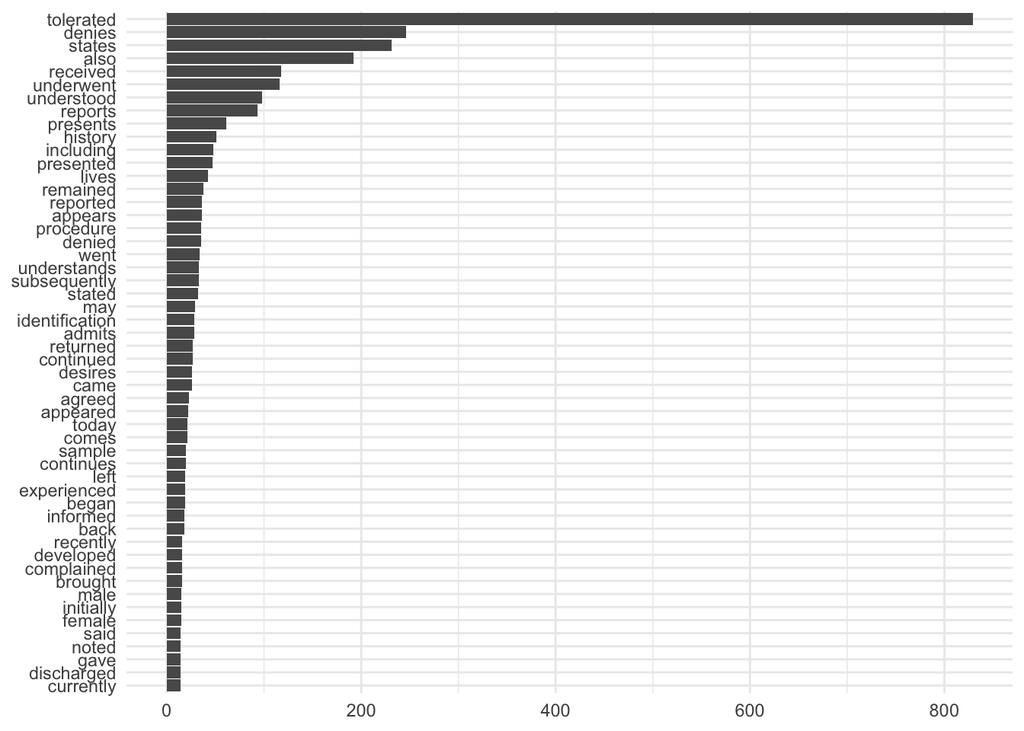

```r
library(stringr)
# e.g., words that come before or after patient
tokens_bigram |>
  filter(str_detect(ngram, regex("\\spatient$|^patient\\s"))) |>
  mutate(word = str_remove(ngram, "patient"),
         word = str_remove_all(word, " ")) |>
  group_by(word) |>
  summarise(n = sum(n)) |>
  slice_max(n, n = 50) |>
  ggplot(aes(reorder(word, n), n)) +
  theme_minimal() +
  labs(y = NULL, x = NULL) +
  geom_bar(stat = "identity") +
  coord_flip()
```

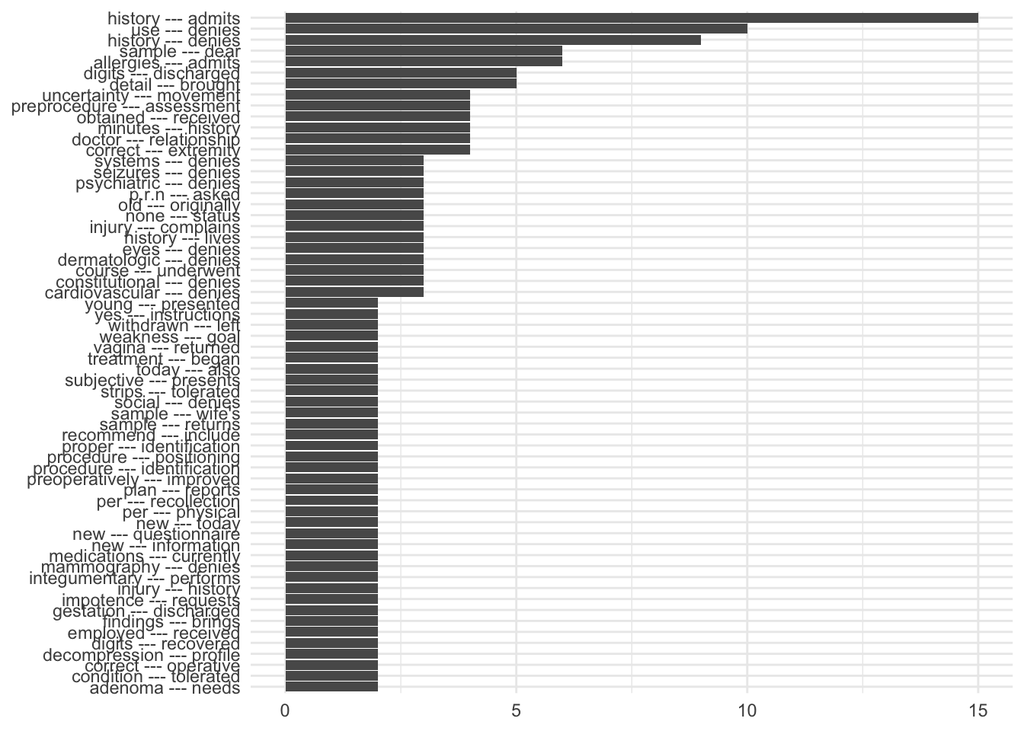

```r
# e.g., pairs of words that come before and after patient
tokens_trigram |>
  filter(str_detect(ngram, regex("\\spatient\\s"))) |>
  mutate(word = str_replace(ngram, "patient", "---")) |>
  group_by(word) |>
  summarise(n = sum(n)) |>
  slice_max(n, n = 50) |>
  ggplot(aes(reorder(word, n), n)) +
  theme_minimal() +
  labs(y = NULL, x = NULL) +
  geom_bar(stat = "identity") +
  coord_flip()
```

# Question 6

Which words are most used in each of the specialties. you can use `group_by()` and `top_n()` `slice_max()` from `dplyr` to have the calculations be done within each specialty. Remember to remove stop words. How about the most 5 used words?

```r
mt_samples |>
  unnest_tokens(word, transcription) |>
  filter(
    !word %in% stopwords("english"),
    !grepl("\\d", word)
  ) |>
  group_by(medical_specialty) |>
  count(word) |>
  slice_max(n, n = 1) |> # ties will appear
  knitr::kable()
```

| medical_specialty | word | n |
| --- | --- | --- |
| Allergy / Immunology | allergies | 4 |
| Allergy / Immunology | used | 4 |
| Bariatrics | patient | 29 |
| Cardiovascular / Pulmonary | normal | 25 |
| Dentistry | removed | 10 |
| Gastroenterology | patient | 835 |
| General Medicine | patient | 1356 |
| Hematology - Oncology | patient | 316 |
| Hospice - Palliative Care | patient | 43 |
| IME-QME-Work Comp etc. | pain | 152 |
| Lab Medicine - Pathology | cm | 35 |
| Lab Medicine - Pathology | tumor | 35 |
| Letters | pain | 80 |
| Nephrology | patient | 348 |
| Neurology | right | 694 |
| Neurosurgery | patient | 374 |
| Obstetrics / Gynecology | patient | 628 |
| Office Notes | normal | 230 |
| Ophthalmology | eye | 456 |
| Orthopedic | patient | 1711 |
| Pain Management | patient | 236 |
| Pediatrics - Neonatal | patient | 247 |
| Physical Medicine - Rehab | patient | 220 |
| Podiatry | foot | 232 |
| Psychiatry / Psychology | patient | 532 |
| Radiology | left | 701 |
| Rheumatology | history | 50 |
| SOAP / Chart / Progress Notes | patient | 537 |
| Sleep Medicine | sleep | 143 |
| Speech - Language | patient | 105 |
| Surgery | patient | 4855 |
| Urology | patient | 776 |

```r
mt_samples |>
  unnest_tokens(word, transcription) |>
  filter(
    !word %in% stopwords("english"),
    !grepl("\\d", word)
  ) |>
  group_by(medical_specialty) |>
  count(word) |>
  slice_max(n, n = 5) |> # ties will appear
  knitr::kable()
```

| medical_specialty | word | n |
| --- | --- | --- |
| Allergy / Immunology | allergies | 4 |
| Allergy / Immunology | used | 4 |
| Allergy / Immunology | allegra | 3 |
| Allergy / Immunology | clear | 3 |
| Allergy / Immunology | prescription | 3 |
| Allergy / Immunology | sprays | 3 |
| Bariatrics | patient | 29 |
| Bariatrics | history | 21 |
| Bariatrics | placed | 21 |
| Bariatrics | abdomen | 20 |
| Bariatrics | procedure | 18 |
| Cardiovascular / Pulmonary | normal | 25 |
| Cardiovascular / Pulmonary | left | 18 |
| Cardiovascular / Pulmonary | trachea | 17 |
| Cardiovascular / Pulmonary | valve | 15 |
| Cardiovascular / Pulmonary | aortic | 12 |
| Dentistry | removed | 10 |
| Dentistry | elevator | 8 |
| Dentistry | tooth | 7 |
| Dentistry | area | 4 |
| Dentistry | aspect | 4 |
| Dentistry | blade | 4 |
| Dentistry | bone | 4 |
| Dentistry | buccal | 4 |
| Dentistry | bur | 4 |
| Dentistry | closed | 4 |
| Dentistry | envelope | 4 |
| Dentistry | flap | 4 |
| Dentistry | follicle | 4 |
| Dentistry | gut | 4 |

[output cut: 141 more lines]

# Question 7 - extra

Find your own insight in the data:

Ideas:

- Use TF-IDF to see if certain words are used more in some specialties then others. Compare the list of words compared to the list from Question 6.

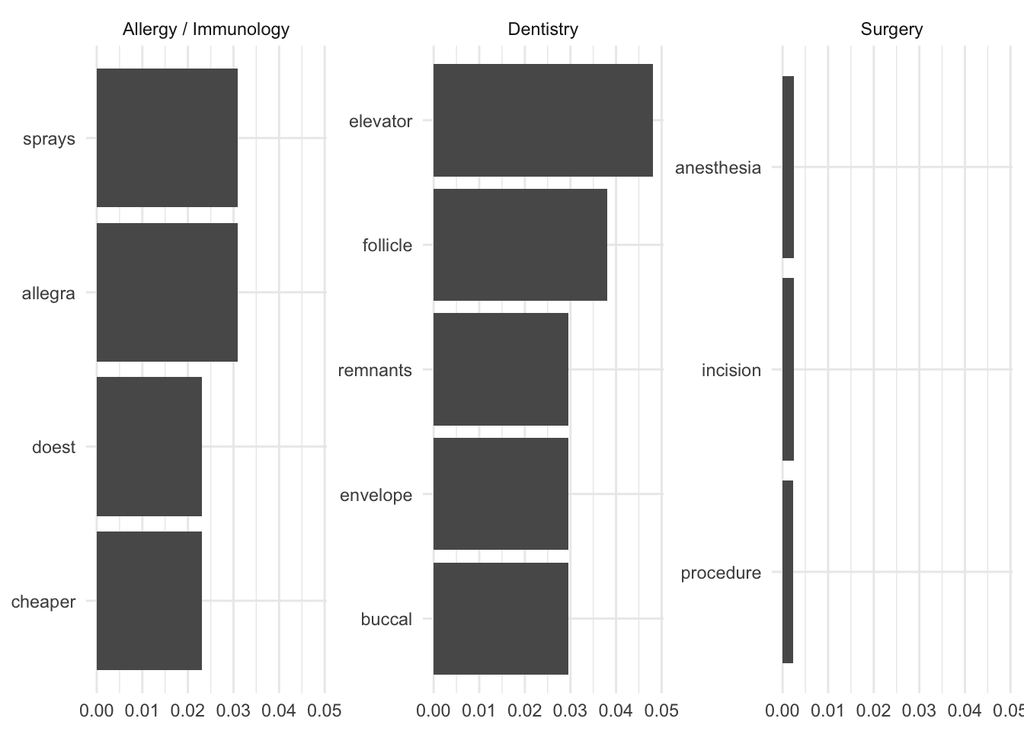

```r
tf_idf_by_specialty <- mt_samples |>
  unnest_tokens(word, transcription) |>
  filter(
    !word %in% stopwords("english"),
    !grepl("[[:digit:]]+", word)
  ) |>
  count(word, medical_specialty) |>
  bind_tf_idf(word, medical_specialty, n)
tf_idf_by_specialty |>
  group_by(medical_specialty) |>
  slice_max(tf_idf, n = 3) |>
  filter(medical_specialty %in% c("Surgery", "Dentistry", "Allergy / Immunology")) |>
  ggplot(aes(reorder(word, tf_idf), tf_idf)) +
  theme_minimal() +
  labs(y = NULL, x = NULL) +
  geom_bar(stat = 'identity') +
  coord_flip() +
  facet_wrap(~ medical_specialty, scales = "free_y")
```

- Sentiment analysis to see if certain specialties are more optimistic than others. How would you define “optimistic”?

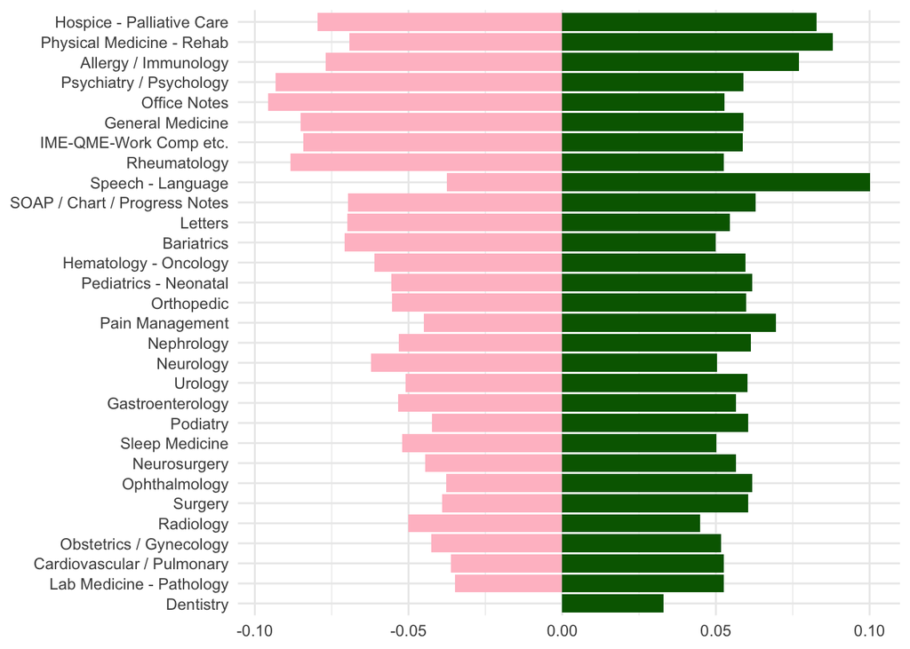

```r
sentiment_list <- get_sentiments("bing")
sentiments_in_med <- tf_idf_by_specialty |>
  left_join(sentiment_list, by = "word") |>
  group_by(medical_specialty) |>
  summarise(
    n_positive = sum(if_else(sentiment == "positive", n, 0), na.rm = TRUE),
    n_negative = sum(if_else(sentiment == "negative", n, 0), na.rm = TRUE) ,
    n = sum(n)
  )
sentiments_in_med |>
  mutate(medical_specialty = reorder(
    medical_specialty, (n_positive + n_negative) / n)) |>
  ggplot(aes(medical_specialty)) +
  theme_minimal() +
  geom_col(aes(y = -n_negative / n), fill = "pink") +
  geom_col(aes(y = n_positive / n), fill = "darkgreen") +
  labs(x = NULL, y = NULL) +
  coord_flip()
```

- Find which specialty writes the longest sentences.

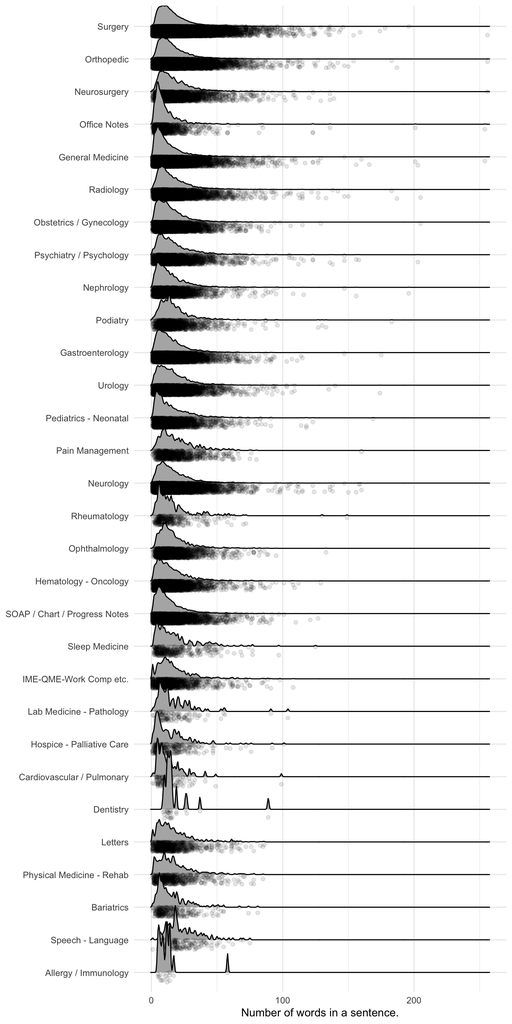

```r
library(ggridges)
mt_samples |>
  select(medical_specialty, transcription) |>
  unnest_tokens(sentence, transcription, token = "sentences") |>
  mutate(n_words = sapply(tokenizers::tokenize_words(sentence), length)) |>
  ggplot() +
  theme_minimal() +
  geom_density_ridges(
    aes(y = reorder(medical_specialty, n_words, max),
        x = n_words, group = medical_specialty),
    bandwidth = .5,
    jittered_points = TRUE, point_alpha = .1,
    position = position_raincloud(height = .3, ygap = 0)
  ) +
  labs(x = "Number of words in a sentence.", y = NULL)
```

# Deliverables

1. Questions 1-7 answered, pdf or html output uploaded to Quercus